# HW3

Myriam Kapon

2023-11-19

# Univariate and Multivariate Analysis and Visualization

This is a dataset with observations about diabetes, including demographics, medical data and a diabetes diagnosis.

## Understanding the Data

The “diabetes” dataset consists of 22 attributes and 403 entries. More analytically:

**Demographics**

- location: (Geographical location)
- age: (Age of the individual)
- gender: (Gender of the individual)
- height: (Height of the individual)
- weight: (Weight of the individual)
- waist: (Waist circumference)
- hip: (Hip circumference)
- waist_hip_ratio: (Waist-hip ratio)
- BMI: (Body Mass Index)

**Medical Data**

- id: (Patient ID)
- total_cholesterol: (Total cholesterol level)
- stabilized.glucose: (Stabilized glucose measurement)
- hdl: (HDL cholesterol - “good” cholesterol)
- total_chol_hdl_ratio: (Ratio of total cholesterol to HDL cholesterol)
- glycosoloatedhgb: (Glycosylated hemoglobin - HbA1c)
- bp.1s: (Systolic blood pressure)
- bp.1d: (Diastolic blood pressure)
- diabetes_diagnosis: (Diabetes diagnosis - 0: non-diabetic, 1: diabetic)

**Categories**

- BMI_cat_3: (Body Mass Index categorized into 3 groups)
- BMI_cat_5: (Body Mass Index categorized into 5 groups)
- age_cat: (Age categorized into groups)
- waist_hip_cat: (Waist-hip ratio categorized into groups)

An overview of the dataset, showing the first 5 entries:

```
    id total_cholesterol stabilized.glucose hdl total_chol_hdl_ratio
1 1000               203                 82  56                  3.6
2 1001               165                 97  24                  6.9
3 1002               228                 92  37                  6.2
4 1003                78                 93  12                  6.5
5 1005               249                 90  28                  8.9
  glycosoloatedhgb   location age gender height weight bp.1s bp.1d waist hip
1             4.31 Buckingham  46      1     62    121   118    59    29  38
2             4.44 Buckingham  29      1     64    218   112    68    46  48
3             4.64 Buckingham  58      1     61    256   190    92    49  57
4             4.63 Buckingham  67      0     67    119   110    50    33  38
5             7.72 Buckingham  64      0     68    183   138    80    44  41
  diabetes_diagnosis      BMI waist_hip_ratio BMI_cat_5 age_cat waist_hip_cat
1                  0 22.12877       0.7631579         1       2             0
2                  0 37.41553       0.9583333         4       1             1
3                  0 48.36549       0.8596491         5       3             1
4                  0 18.63600       0.8684211         1       4             0
5                  1 27.82202       1.0731707         2       3             1
  BMI_cat_3
1         1
2         3
3         3
4         1
5         2
```

Before starting the analysis, some information about the health of the dataset will be gathered. This will ensure that the analysis is meaningful and that no problems will arise later on.

```
'data.frame':   403 obs. of  22 variables:
 $ id                  : num  1000 1001 1002 1003 1005 ...
 $ total_cholesterol   : num  203 165 228 78 249 248 195 227 177 263 ...
 $ stabilized.glucose  : num  82 97 92 93 90 94 92 75 87 89 ...
 $ hdl                 : num  56 24 37 12 28 69 41 44 49 40 ...
 $ total_chol_hdl_ratio: num  3.6 6.9 6.2 6.5 8.9 ...
 $ glycosoloatedhgb    : num  4.31 4.44 4.64 4.63 7.72 ...
 $ location            : chr  "Buckingham" "Buckingham" "Buckingham" "Buckingham" ...
 $ age                 : num  46 29 58 67 64 34 30 37 45 55 ...
 $ gender              : Factor w/ 2 levels "0","1": 2 2 2 1 1 1 1 1 1 2 ...
 $ height              : num  62 64 61 67 68 71 69 59 69 63 ...
 $ weight              : num  121 218 256 119 183 190 191 170 166 202 ...
 $ bp.1s               : num  118 112 190 110 138 132 161 150 160 108 ...
 $ bp.1d               : num  59 68 92 50 80 86 112 98 80 72 ...
 $ waist               : num  29 46 49 33 44 36 46 34 34 45 ...
 $ hip                 : num  38 48 57 38 41 42 49 39 40 50 ...
 $ diabetes_diagnosis  : Factor w/ 2 levels "0","1": 1 1 1 1 2 1 1 1 1 1 ...
 $ BMI                 : num  22.1 37.4 48.4 18.6 27.8 ...
 $ waist_hip_ratio     : num  0.763 0.958 0.86 0.868 1.073 ...
 $ BMI_cat_5           : Factor w/ 5 levels "1","2","3","4",..: 1 4 5 1 2 2 2 3 1 4 ...
 $ age_cat             : Factor w/ 4 levels "1","2","3","4": 2 1 3 4 3 1 1 2 2 3 ...
 $ waist_hip_cat       : Factor w/ 2 levels "0","1": 1 2 2 1 2 1 2 1 1 2 ...
 $ BMI_cat_3           : Factor w/ 3 levels "1","2","3": 1 3 3 1 2 2 2 3 1 3 ...
```

As can be seen, the health of the dataset is good, since all variables are of the correct type. The variables with type “Factor” have been manually factorized. Moving on to missing values:

```
                  id    total_cholesterol   stabilized.glucose
                   0                    1                    0
                 hdl total_chol_hdl_ratio     glycosoloatedhgb
                   1                    1                   13
            location                  age               gender
                   0                    0                    0
              height               weight                bp.1s
                   5                    1                    0
               bp.1d                waist                  hip
                   0                    0                    0
  diabetes_diagnosis                  BMI      waist_hip_ratio
                  13                    6                    0
           BMI_cat_5              age_cat        waist_hip_cat
                  12                    0                   19
           BMI_cat_3
                  12
```

There are a few missing values in the set, but they will not be dealt with in this part of the analysis. Variable waist_hip_cat has the most NA’s (19), which is interesting since neither waist or hip have any NA’s.

With all of this knowledge, the dataset analysis is ready to begin.

## Univariate Analysis

A quick summary of the demographic data:

```
      age        age_cat   location         gender      height
 Min.   :19.00   1:102   Length:403         0:169   Min.   :52.00
 1st Qu.:34.00   2:130   Class :character   1:234   1st Qu.:63.00
 Median :45.00   3:107   Mode  :character           Median :66.00
 Mean   :46.85   4: 64                              Mean   :66.02
 3rd Qu.:60.00                                      3rd Qu.:69.00
 Max.   :92.00                                      Max.   :76.00
                                                    NA's   :5
     weight          waist            hip        waist_hip_ratio  waist_hip_cat
 Min.   : 99.0   Min.   :26.00   Min.   :30.00   Min.   :0.6818   0   :101
 1st Qu.:151.0   1st Qu.:33.00   1st Qu.:39.00   1st Qu.:0.8295   1   :283
 Median :172.5   Median :37.00   Median :42.00   Median :0.8788   NA's: 19
 Mean   :177.6   Mean   :37.89   Mean   :43.05   Mean   :0.8805
 3rd Qu.:200.0   3rd Qu.:41.00   3rd Qu.:46.00   3rd Qu.:0.9250
 Max.   :325.0   Max.   :56.00   Max.   :64.00   Max.   :1.1429
 NA's   :1
      BMI        BMI_cat_3  BMI_cat_5
 Min.   :15.20   1   :122   1   :122
 1st Qu.:24.13   2   :120   2   :120
 Median :27.80   3   :149   3   : 88
 Mean   :28.78   NA's: 12   4   : 32
 3rd Qu.:32.24              5   : 29
 Max.   :55.78              NA's: 12
 NA's   :6
```

Observations:

- Age: The dataset covers a range of ages from 19 to 92 years, with a mean age of approximately 46.85 years. The majority of individuals fall between 34 and 60 years old.
- BMI (Body Mass Index) averages at 28.78, indicating an overweight range, with a fair amount of variability.
- Waist-Hip Ratio has a mean of 0.88, which indicates an average waist size slightly smaller than the hips. This might point towards certain related to body shape or health conditions.
- Categorical Variables: Some categories show imbalance and it should be explored visually. The high range in weight, waist, hip, and BMI indicates significant variability, possibly implying a diverse sample.

And the medical data:

```
 total_cholesterol stabilized.glucose      hdl         total_chol_hdl_ratio
 Min.   : 78.0     Min.   : 48.0      Min.   : 12.00   Min.   : 1.500
 1st Qu.:179.0     1st Qu.: 81.0      1st Qu.: 38.00   1st Qu.: 3.200
 Median :204.0     Median : 89.0      Median : 46.00   Median : 4.200
 Mean   :207.8     Mean   :106.7      Mean   : 50.45   Mean   : 4.522
 3rd Qu.:230.0     3rd Qu.:106.0      3rd Qu.: 59.00   3rd Qu.: 5.400
 Max.   :443.0     Max.   :385.0      Max.   :120.00   Max.   :19.300
 NA's   :1                            NA's   :1        NA's   :1
 glycosoloatedhgb     bp.1s           bp.1d        diabetes_diagnosis
 Min.   : 2.68    Min.   : 90.0   Min.   : 48.00   0   :330
 1st Qu.: 4.38    1st Qu.:121.5   1st Qu.: 75.00   1   : 60
 Median : 4.84    Median :136.0   Median : 82.00   NA's: 13
 Mean   : 5.59    Mean   :136.9   Mean   : 83.37
 3rd Qu.: 5.60    3rd Qu.:146.5   3rd Qu.: 91.00
 Max.   :16.11    Max.   :250.0   Max.   :124.00
 NA's   :13
```

Observations:

- Total Cholesterol to HDL Ratio has an average of 4.52, indicating an average total cholesterol level about 4.5 times higher than HDL cholesterol.
- Glucose Levels (Stabilized Glucose): The stabilized glucose measurements in this dataset display a considerable variability, ranging from 48 to 385 mg/dL, with an average around 106.7 mg/dL. This wide range suggests diverse blood glucose levels among individuals in the sample. Higher glucose levels, especially above the normal range (usually 70-99 mg/dL when fasting), might indicate hyperglycemia, a key characteristic of diabetes.
- Glycosylated Hemoglobin (HbA1c): The dataset portrays diverse HbA1c levels, ranging from 2.68% to 16.11%, with an average of approximately 5.59%. The median value at 4.84% suggests that a significant portion of individuals in the sample have relatively well-controlled blood glucose over the past few months. Higher HbA1c values typically indicate poorer long-term glucose control, posing higher risks for diabetes-related complications.

Moving to a visual analysis of the data:

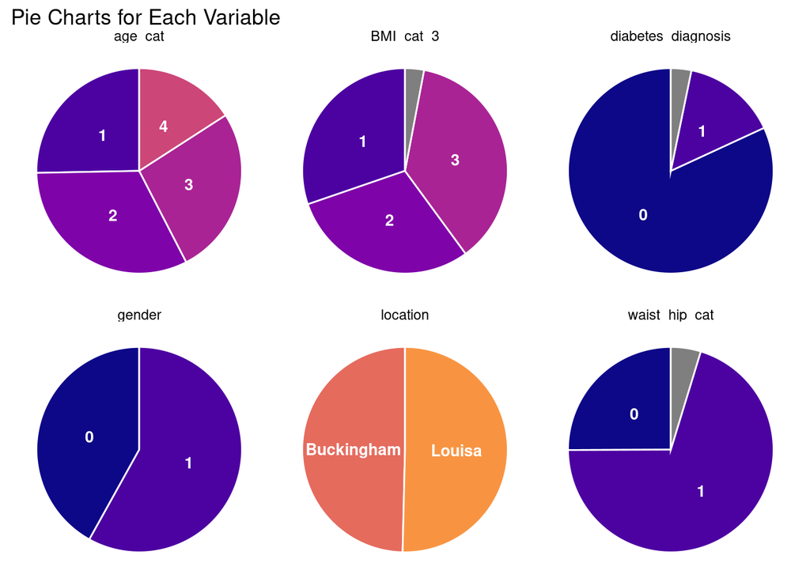

These findings show that the dataset is quite unbalanced and any analysis performed might be biased. Lastly, some variables have missing values (grey color), with waist_hip_cat having the most.

It is time to plot the continuous data and, again, a facet plot is created with a bar chart for every variable.

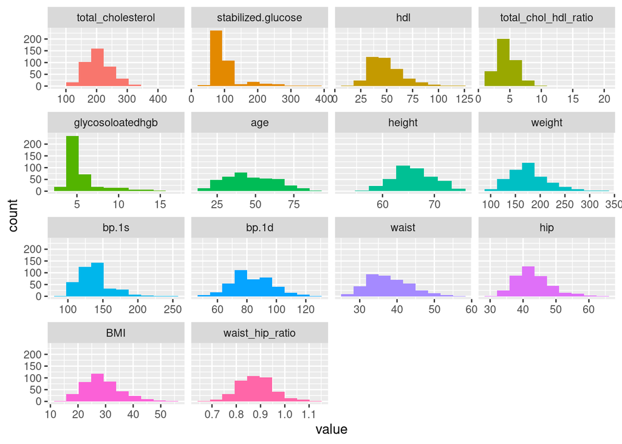

Observations:

Data distributions mostly resemble a normal curve and they appear to have right skewerness, which indicates the existance of outliers. Bivariate analysis will be necessary to decide which to impute/delete and which to keep as interesting observations.

The same observations can be made about age and waist_hip_ratio as their categorical counterparts, but BMI seems to have a right tail. The most interesting plots are the ones for stabilized.glucose and glycosoloatedhgb which will be further analyzed below.

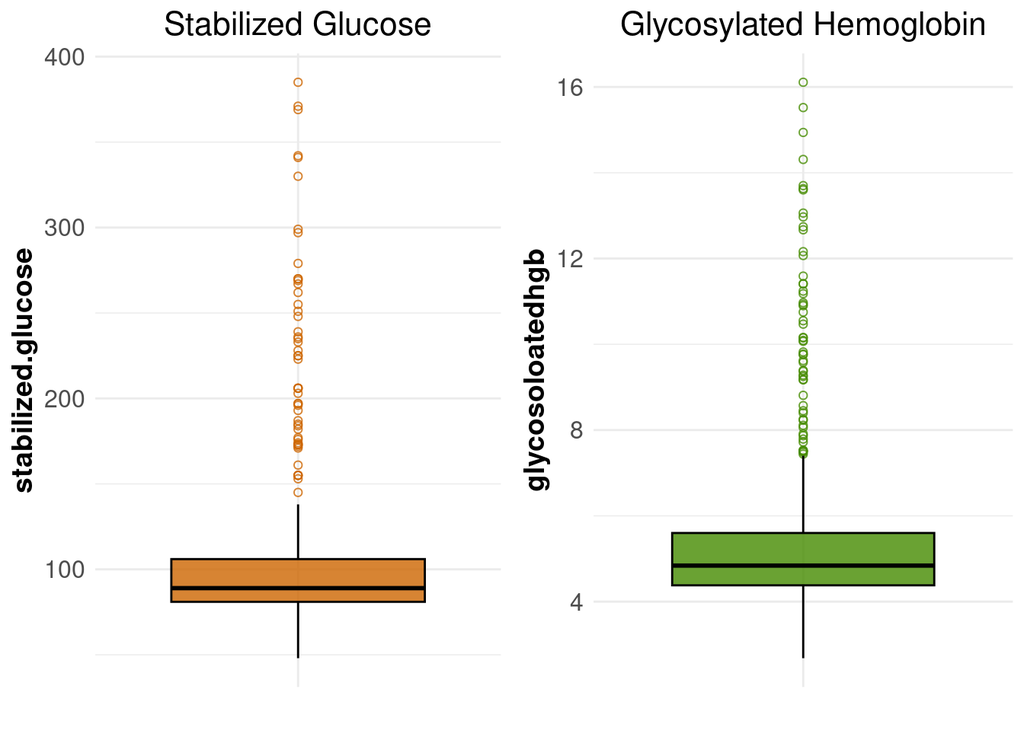

Observations:

Stabilized glucose has a lot of high-range outliers. Since glucose plays a role in the detection of diabetes, all of those outliers could potentially belong to observations of diabetic people. For this reason, the outliers will not be removed. The same can be said for Glycosylated Hemoglobin.

### Key Findings

- There’s an imbalance in certain categorical variables.
- Glucose-related variables (stabilized glucose and glycosylated hemoglobin) have significant variability and potential outliers.
- The dataset has diverse demographic and medical profiles, indicating a need for further bivariate and multivariate analyses to explore relationships between variables.

Moving to multivariate analysis will allow a deeper exploration of relationships between variables and potential predictive factors related to diabetes diagnosis or other health conditions within the dataset.

## Multivariate Analysis

Observations:

These can further be confirmed by a correlation matrix using the Spearman method:

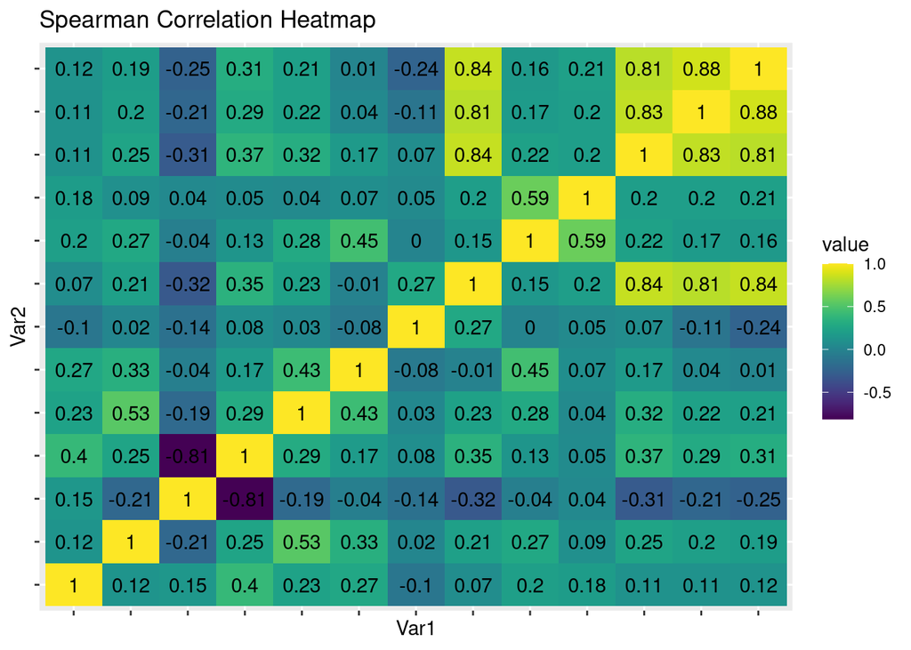

Observations:

- The strongest relationship is between hip and BMI (0.88). While one would expect that height and weight are correlated, it doesn’t appear to be the case for this dataset.
- The strong negative correlation between total_chol_hdl_ratio and hdl (-0.81) essentially indicates an expected inverse relationship, which makes sense due to how total_chol_hdl_ratio is computed.
- The stabilized glucose and glycated hemoglobin correlation (0.53) indicates a moderate positive linear relationship between the two variables.

Since stabilized glucose and glycated hemoglobin appear both to have a linear relationship and to be good predictors for diagnosing diabetes against all other variables, they will be plotted plotted together.

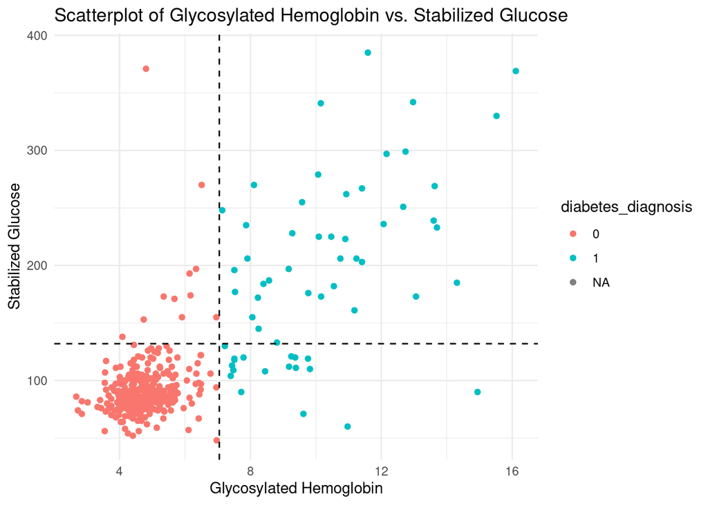

Immediately discernible from the plot is the significance of Glycated Hemoglobin as a robust predictor for diabetes diagnosis. Patients exhibiting a Glycated Hemoglobin level surpassing 7 are more likely to have diabetes. Conversely, while not as distinct, Stabilized Glucose demonstrates some discernible separation, particularly around the threshold value of 132.

Note: The dashed lines separating the diabetic vs not diabetic people were drawn using visual feedback and it would be meaningful to use a technique like linear discriminant analysis (LDA) or logistic regression to identify the boundary in a future analysis.

It will also be meaningful to explore the relationship between the demographic data and the diabetes diagnosis.

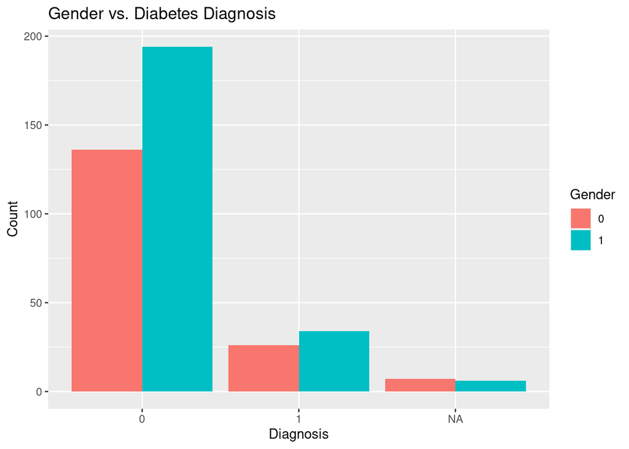

Gender Observations:

- For non-diabetics, there are more people of gender 1
- For diabetics, there are slightly more people of gender 1

This makes sense since gender is an unbalanced category favoring gender 1 nad doesn’t provide any helpful insight

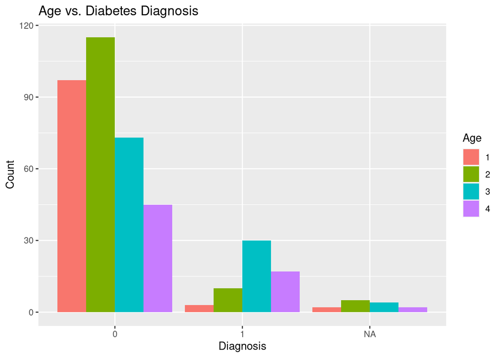

Age Observations:

- More people of age 1 and 2 don’t have diabetes.
- More people of age 3 and 4 have diabetes. Younger people are more likely to not have diabetes, while older people are more likely to be diabetic. This shows a slight trend between age and diabetes.

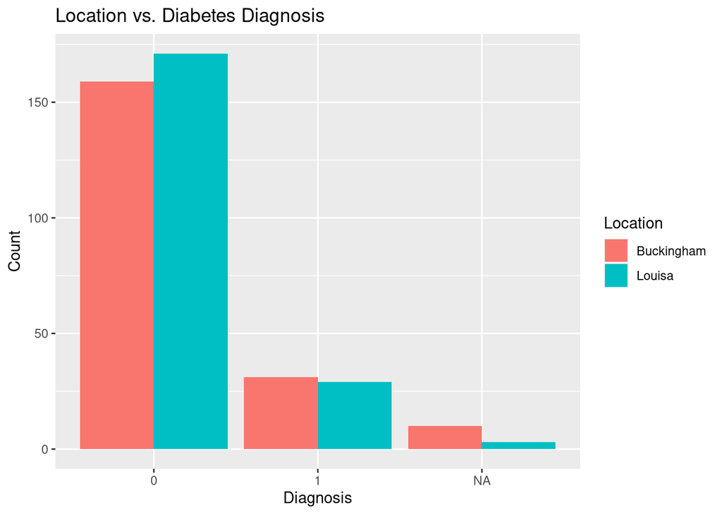

Location Observations:

- People from both locations are equally likely to have or not have diabetes
- People from Buckingham have more missing diagnosis. This shows that location is unrelated to diabetes in this dataset.

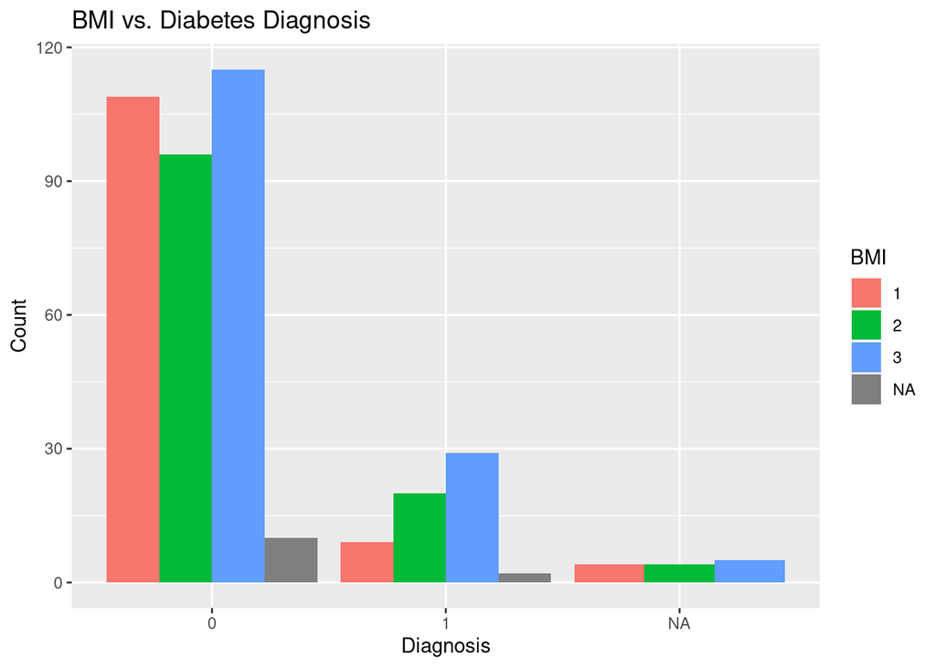

BMI Observations:

- People with higher BMIs are more likely to have diabetes. This is expected, since there have been found links between obesity and diabetes in other studies.

### Key Findings

- Predictors: Glycated Hemoglobin (>7), Stabilized Glucose (>132) and high BMI strongly relate to diabetes.
- Demographics: Older age groups exhibit higher diabetes prevalence.
- Associations: Strong correlations exist between anthropometric measures.
- Visualization: Glycated Hemoglobin distinctly separates diabetic cases.

# Part B: Evaluation of Missing Values Management Techniques

```
 total_cholesterol      age            gender           weight
 Min.   : 78.0     Min.   :19.00   Min.   :0.0000   Min.   : 99.0
 1st Qu.:179.0     1st Qu.:34.00   1st Qu.:0.0000   1st Qu.:151.0
 Median :204.0     Median :45.00   Median :1.0000   Median :172.5
 Mean   :207.8     Mean   :46.85   Mean   :0.5806   Mean   :177.6
 3rd Qu.:230.0     3rd Qu.:60.00   3rd Qu.:1.0000   3rd Qu.:200.0
 Max.   :443.0     Max.   :92.00   Max.   :1.0000   Max.   :325.0
 NA's   :1                                          NA's   :1
```

The given dataset without implementing any techniques:

```
 total_cholesterol      age            gender           weight
 Min.   :118.0     Min.   :19.00   Min.   :0.0000   Min.   : 99.0
 1st Qu.:179.0     1st Qu.:34.75   1st Qu.:0.0000   1st Qu.:151.0
 Median :203.0     Median :45.00   Median :1.0000   Median :173.0
 Mean   :207.6     Mean   :47.10   Mean   :0.5943   Mean   :177.1
 3rd Qu.:229.0     3rd Qu.:60.00   3rd Qu.:1.0000   3rd Qu.:199.0
 Max.   :443.0     Max.   :92.00   Max.   :1.0000   Max.   :320.0
 NA's   :114       NA's   :135     NA's   :122      NA's   :114
```

A quick visual analysis of the missing values:

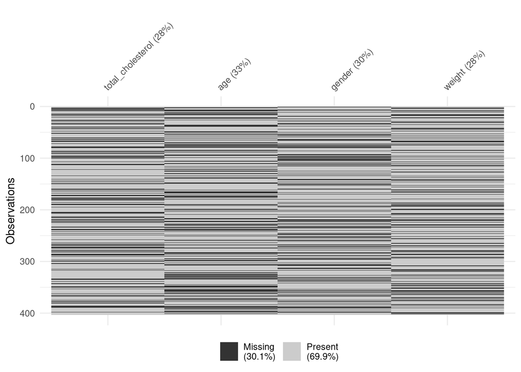

The number of NA’s is large, contributing to 30% of the data. It is apparent that a method to deal with missing values must be implemented. There doesn’t appear to be a pattern in the way the NA values are distributed and, to investigate further, a cluster is applied to the plot:

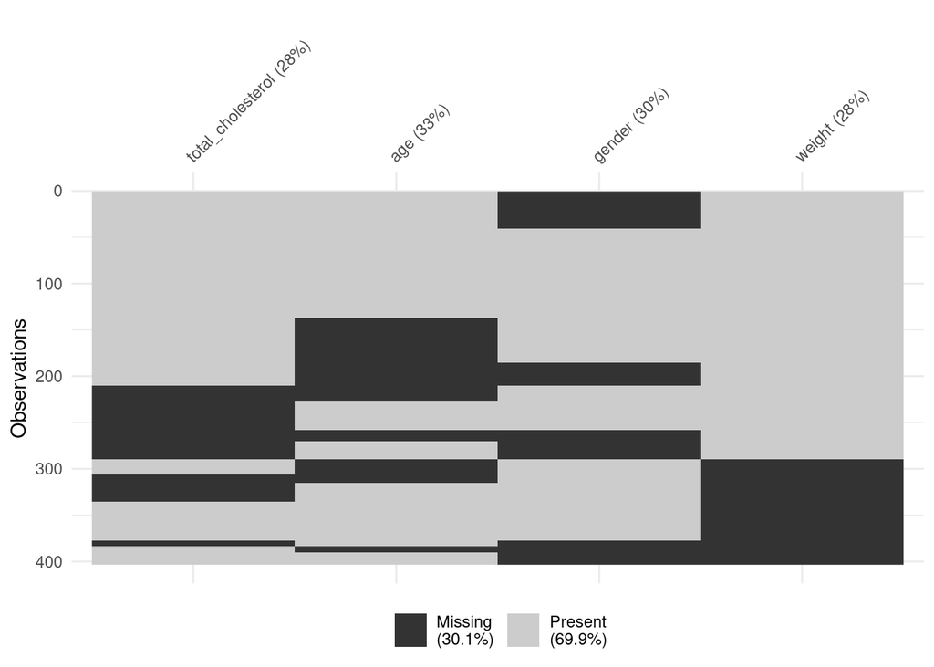

There’s still a lot of noise in the plot, alluding to the missing values being MCAR ((Missing Completely At Random))

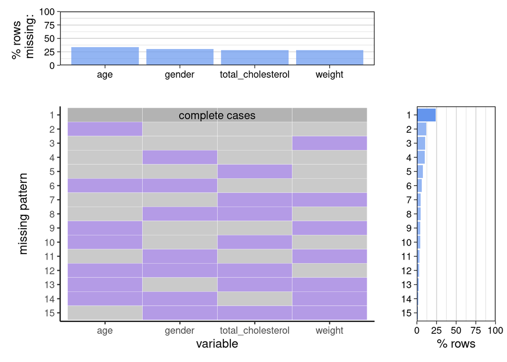

## Deletion

### List wise Deletion

```
 total_cholesterol      age       gender     weight
 Min.   :136.0     Min.   :20.0   0:43   Min.   : 99.0
 1st Qu.:179.0     1st Qu.:35.0   1:54   1st Qu.:153.0
 Median :208.0     Median :45.0          Median :169.0
 Mean   :209.9     Mean   :46.9          Mean   :175.9
 3rd Qu.:228.0     3rd Qu.:59.0          3rd Qu.:200.0
 Max.   :342.0     Max.   :92.0          Max.   :290.0
```

Comparison:

In summary, the datasets are closer in terms of age and weight, with relatively minor differences, while showing more significant discrepancies in total cholesterol and gender distribution. The second dataset particularly deviates more from the first in terms of total cholesterol and gender representation. It is incredible that the dataset changes so little with so many observations gone.

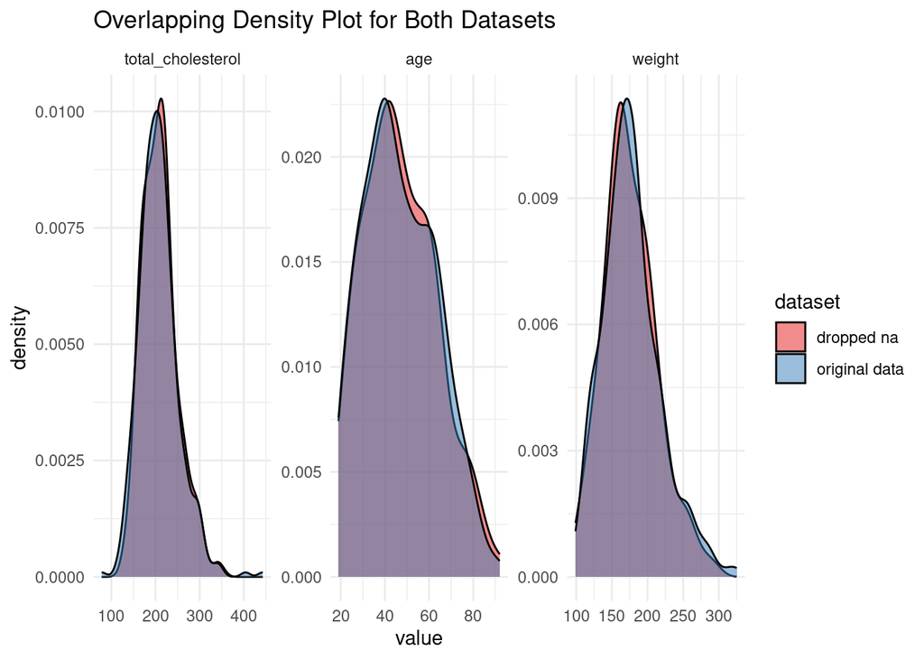

The density function doesn’t appear to change much, only becomes less defined.

## Imputation

To implement the different imputation methods, the MICE package will be used. They will be compared to the original daatset using the Mean Absolute Error (MAE), meaning an average of absolute errors.

### Mean Imputation

Mean imputation is a simple method for handling missing data by replacing missing values with the mean (average) of the non-missing values for that particular variable.

### PMM

Predictive Mean Matching (PMM) is an imputation method used to fill in missing values in a dataset. PMM imputation doesn’t generate new values but instead finds observed (non-missing) values from the dataset that are similar to the missing value based on their relationships with other variables.

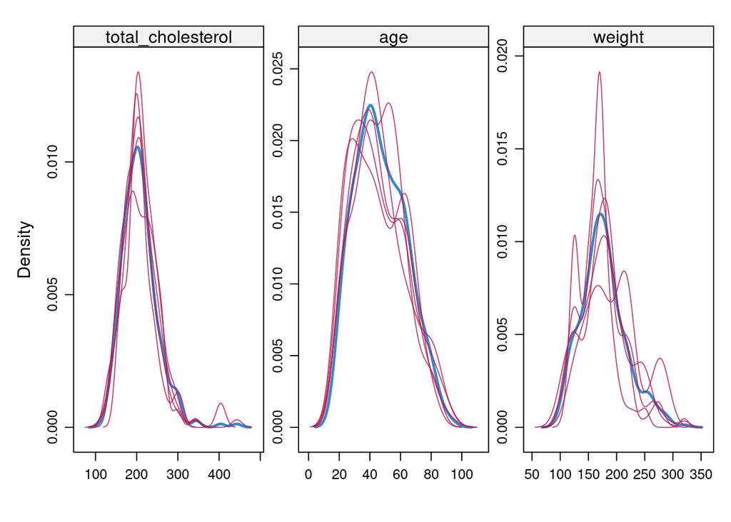

Mean Absolute Error (MAE):

```
total_cholesterol               age            gender            weight
        12.370647          6.138958               NaN         12.597015
```